# Random Forest – Predicción del Nivel de Estrés en Adolescentes

Zulema Luque

2026-05-09

# 1 Introducción

En este análisis aplicamos **Random Forest** para predecir el `stress_level` (nivel de estrés, variable numérica) en un conjunto de datos de salud mental adolescente. Se siguen los mismos pasos del ejemplo de regresión con Boston: modelo base → optimización de `num.trees` (OOB y CV) → optimización de `mtry` → Grid Search → modelo final → importancia de predictores → comparación con árbol de decisión.

# 2 Librerías

```r
library(dplyr)
library(tidyr)
library(ggplot2)
library(tidymodels)
library(ranger)
library(rpart)
library(rpart.plot)
library(doParallel)
library(recipes)
library(workflows)
library(readxl)
library(tibble)
```

# 3 Carga y preparación de datos

```r
datos <- read_excel("datosestresyansiedad.xlsx")
head(datos)
```

```
## # A tibble: 6 × 13
##     age gender daily_social_media_hours platform_usage sleep_hours
##   <dbl> <chr>                     <dbl> <chr>                <dbl>
## 1    14 male                        7.9 Instagram              7.4
## 2    19 female                      1.9 TikTok                 8
## 3    17 female                      1.3 Instagram              7.6
## 4    15 male                        7.4 TikTok                 6.9
## 5    15 female                      4.7 Both                   4.9
## 6    19 female                      7.4 Both                   4.4
## # ℹ 8 more variables: screen_time_before_sleep <dbl>,
## #   academic_performance <dbl>, physical_activity <dbl>,
## #   social_interaction_level <chr>, anxiety_level <dbl>, addiction_level <dbl>,
## #   depression_label <dbl>, stress_level <dbl>
```

```r
# Convertir variables categóricas a factor
datos$gender                   <- as.factor(datos$gender)
datos$platform_usage           <- as.factor(datos$platform_usage)
datos$social_interaction_level <- as.factor(datos$social_interaction_level)
datos$depression_label         <- as.factor(datos$depression_label)
str(datos)
```

```
## tibble [1,200 × 13] (S3: tbl_df/tbl/data.frame)
##  $ age                     : num [1:1200] 14 19 17 15 15 19 18 16 19 15 ...
##  $ gender                  : Factor w/ 2 levels "female","male": 2 1 1 2 1 1 1 2 1 2 ...
##  $ daily_social_media_hours: num [1:1200] 7.9 1.9 1.3 7.4 4.7 7.4 2.5 4 3.3 1.9 ...
##  $ platform_usage          : Factor w/ 3 levels "Both","Instagram",..: 2 3 2 3 1 1 2 1 3 3 ...
##  $ sleep_hours             : num [1:1200] 7.4 8 7.6 6.9 4.9 4.4 6.4 4.2 5 4.9 ...
##  $ screen_time_before_sleep: num [1:1200] 2.9 2.9 0.5 1.6 3 2.4 2.4 0.5 2.1 1.5 ...
##  $ academic_performance    : num [1:1200] 3.01 3.22 3.92 3.48 2.37 2.63 2.63 2.4 2.04 3.77 ...
##  $ physical_activity       : num [1:1200] 1.5 0.8 0 0.8 1.4 0.6 0.7 1.3 0.9 1.1 ...
##  $ social_interaction_level: Factor w/ 3 levels "high","low","medium": 2 1 1 3 3 1 2 2 1 1 ...
##  $ anxiety_level           : num [1:1200] 2 1 4 7 5 5 2 10 10 1 ...
##  $ addiction_level         : num [1:1200] 1 10 2 9 2 7 5 5 9 4 ...
##  $ depression_label        : Factor w/ 2 levels "0","1": 1 1 1 1 1 1 1 1 1 1 ...
##  $ stress_level            : num [1:1200] 2 8 2 1 3 3 2 6 1 1 ...
```

# 4 Partición de la data

```r
set.seed(123)
train      <- sample(1:nrow(datos), size = nrow(datos) * 0.8)
data_train <- datos[train, ]
data_test  <- datos[-train, ]

cat("Train:", nrow(data_train), "    Test:", nrow(data_test), "\n")
```

```
## Train: 960     Test: 240
```

# 5 Modelo base (referencia)

El modelo base utiliza solo **12 árboles** para tener una línea de referencia antes de optimizar.

```r
modelo_base <- ranger(
  formula   = stress_level ~ .,
  data      = data_train,
  num.trees = 12,
  seed      = 123
)

print(modelo_base)
```

```
## Ranger result
##
## Call:
##  ranger(formula = stress_level ~ ., data = data_train, num.trees = 12,      seed = 123)
##
## Type:                             Regression
## Number of trees:                  12
## Sample size:                      960
## Number of independent variables:  12
## Mtry:                             3
## Target node size:                 5
## Variable importance mode:         none
## Splitrule:                        variance
## OOB prediction error (MSE):       10.27046
## R squared (OOB):                  -0.2278718
```

```r
pred_base <- predict(modelo_base, data = data_test)$predictions
rmse_base <- sqrt(mean((pred_base - data_test$stress_level)^2))

cat("RMSE Modelo Base (12 árboles):", round(rmse_base, 2), "\n")
```

```
## RMSE Modelo Base (12 árboles): 3.06
```

# 6 Optimización: número de árboles

## 6.1 Estrategia 1 – OOB (Out-of-Bag)

```r
num_trees_range <- seq(1, 400, 20)
results_oob <- tibble(
  n_arboles  = num_trees_range,
  train_rmse = NA_real_,
  oob_rmse   = NA_real_
)

for (i in seq_along(num_trees_range)) {
  modelo <- ranger(
    formula   = stress_level ~ .,
    data      = data_train,
    num.trees = num_trees_range[i],
    oob.error = TRUE,
    seed      = 123
  )
  pred_train  <- predict(modelo, data = data_train)$predictions
  results_oob$train_rmse[i] <- sqrt(mean((pred_train - data_train$stress_level)^2))
  results_oob$oob_rmse[i]   <- sqrt(modelo$prediction.error)
}

optimal_trees_oob <- results_oob$n_arboles[which.min(results_oob$oob_rmse)]
cat("Óptimo num.trees (OOB):", optimal_trees_oob, "\n")
```

```
## Óptimo num.trees (OOB): 341
```

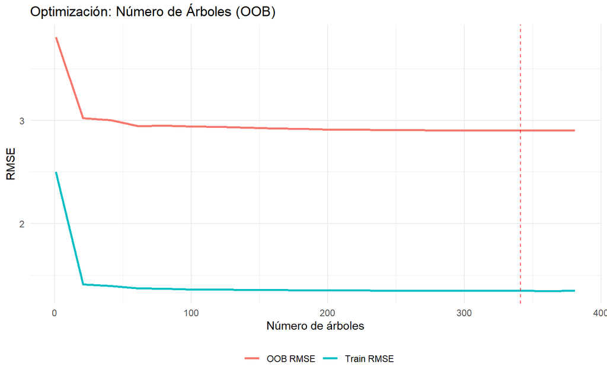

```r
ggplot(results_oob, aes(x = n_arboles)) +
  geom_line(aes(y = train_rmse, color = "Train RMSE"), linewidth = 1) +
  geom_line(aes(y = oob_rmse,   color = "OOB RMSE"),   linewidth = 1) +
  geom_vline(xintercept = optimal_trees_oob, linetype = "dashed",
             color = "red", alpha = 0.7) +
  labs(
    title = "Optimización: Número de Árboles (OOB)",
    x     = "Número de árboles",
    y     = "RMSE",
    color = ""
  ) +
  theme_minimal() +
  theme(legend.position = "bottom")
```

## 6.2 Estrategia 2 – 5-Fold Cross-Validation

```r
num_trees_range  <- seq(1, 400, 10)
results_cv_trees <- tibble(
  n_arboles  = num_trees_range,
  train_rmse = NA_real_,
  cv_rmse    = NA_real_
)

for (i in seq_along(num_trees_range)) {
  modelo <- rand_forest(mode = "regression", trees = num_trees_range[i]) %>%
    set_engine("ranger", seed = 123)

  set.seed(1234)
  cv_folds <- vfold_cv(data_train, v = 5)

  cv_fit <- fit_resamples(
    preprocessor = stress_level ~ .,
    object       = modelo,
    resamples    = cv_folds,
    metrics      = metric_set(rmse)
  )

  cv_rmse    <- collect_metrics(cv_fit)$mean[1]
  modelo_fit <- fit(modelo, stress_level ~ ., data = data_train)
  pred_train <- predict(modelo_fit, new_data = data_train)$.pred

  results_cv_trees$train_rmse[i] <- sqrt(mean((pred_train - data_train$stress_level)^2))
  results_cv_trees$cv_rmse[i]    <- cv_rmse
}

optimal_trees_cv <- results_cv_trees$n_arboles[which.min(results_cv_trees$cv_rmse)]
cat("Óptimo num.trees (CV):", optimal_trees_cv, "\n")
```

```
## Óptimo num.trees (CV): 301
```

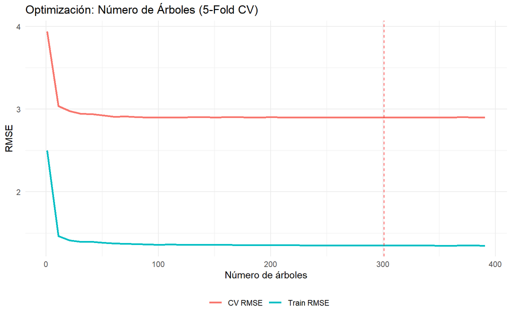

```r
ggplot(results_cv_trees, aes(x = n_arboles)) +
  geom_line(aes(y = train_rmse, color = "Train RMSE"), linewidth = 1) +
  geom_line(aes(y = cv_rmse,    color = "CV RMSE"),    linewidth = 1) +
  geom_vline(xintercept = optimal_trees_cv, linetype = "dashed",
             color = "red", alpha = 0.7) +
  labs(
    title = "Optimización: Número de Árboles (5-Fold CV)",
    x     = "Número de árboles",
    y     = "RMSE",
    color = ""
  ) +
  theme_minimal() +
  theme(legend.position = "bottom")
```

# 7 Optimización: mtry (OOB)

`mtry` controla cuántas variables se consideran en cada split y es el hiperparámetro más influyente en Random Forest.

```r
mtry_range       <- 1:(ncol(data_train) - 1)
results_oob_mtry <- tibble(
  mtry       = mtry_range,
  train_rmse = NA_real_,
  oob_rmse   = NA_real_
)

for (i in seq_along(mtry_range)) {
  modelo <- ranger(
    formula   = stress_level ~ .,
    data      = data_train,
    num.trees = 50,
    mtry      = mtry_range[i],
    oob.error = TRUE,
    seed      = 123
  )
  pred_train  <- predict(modelo, data = data_train)$predictions
  results_oob_mtry$train_rmse[i] <- sqrt(mean((pred_train - data_train$stress_level)^2))
  results_oob_mtry$oob_rmse[i]   <- sqrt(modelo$prediction.error)
}

optimal_mtry_oob <- results_oob_mtry$mtry[which.min(results_oob_mtry$oob_rmse)]
cat("Óptimo mtry (OOB):", optimal_mtry_oob, "\n")
```

```
## Óptimo mtry (OOB): 1
```

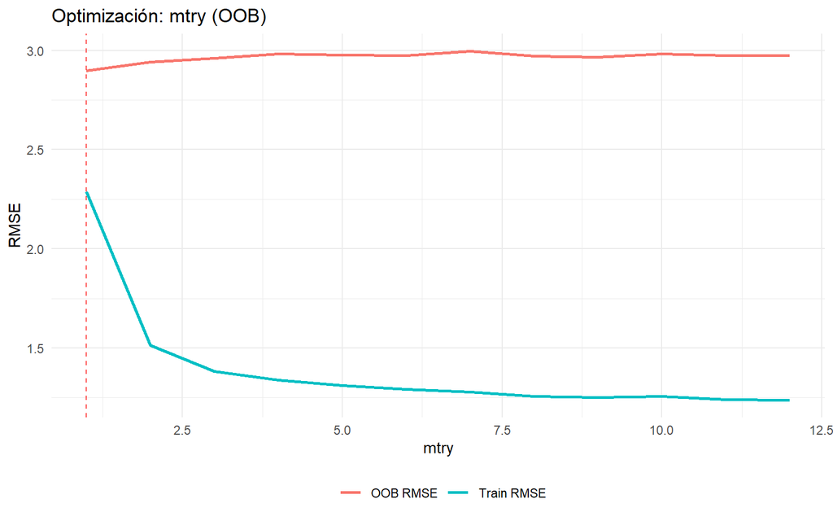

```r
ggplot(results_oob_mtry, aes(x = mtry)) +
  geom_line(aes(y = train_rmse, color = "Train RMSE"), linewidth = 1) +
  geom_line(aes(y = oob_rmse,   color = "OOB RMSE"),   linewidth = 1) +
  geom_vline(xintercept = optimal_mtry_oob, linetype = "dashed",
             color = "red", alpha = 0.7) +
  labs(
    title = "Optimización: mtry (OOB)",
    x     = "mtry",
    y     = "RMSE",
    color = ""
  ) +
  theme_minimal() +
  theme(legend.position = "bottom")
```

# 8 Grid Search con validación cruzada

```r
# Modelo con hiperparámetros a tunear
modelo_tune <- rand_forest(
  mode  = "regression",
  mtry  = tune(),
  trees = tune()
) %>%
  set_engine(
    engine    = "ranger",
    max.depth = tune(),
    seed      = 123
  )

# Preprocesado (dummies para variables categóricas)
transformer <- recipe(stress_level ~ ., data = data_train) %>%
  step_dummy(all_nominal_predictors())

# Workflow
workflow_modelado <- workflow() %>%
  add_recipe(transformer) %>%
  add_model(modelo_tune)

# Grid de hiperparámetros
n_pred <- ncol(data_train) - 1
hiperpar_grid <- expand_grid(
  trees     = c(50, 100, 500, 1000),
  mtry      = c(3, 5, 7, n_pred),
  max.depth = c(1, 3, 10, 20)
)

cat("Número de combinaciones:", nrow(hiperpar_grid), "\n")
```

```
## Número de combinaciones: 64
```

```r
set.seed(1234)
cv_folds <- vfold_cv(data_train, v = 5, strata = stress_level)

cl <- makePSOCKcluster(parallel::detectCores() - 1)
registerDoParallel(cl)

grid_fit <- tune_grid(
  object    = workflow_modelado,
  resamples = cv_folds,
  metrics   = metric_set(rmse),
  grid      = hiperpar_grid,
  control   = control_grid(verbose = FALSE)
)

stopCluster(cl)
```

```r
best_params <- show_best(grid_fit, metric = "rmse", n = 5)
print(best_params)
```

```
## # A tibble: 5 × 9
##    mtry trees max.depth .metric .estimator  mean     n std_err .config
##   <dbl> <dbl>     <dbl> <chr>   <chr>      <dbl> <int>   <dbl> <chr>
## 1    12   500         1 rmse    standard    2.85     5  0.0317 pre0_mod57_post0
## 2    12    50         1 rmse    standard    2.85     5  0.0307 pre0_mod49_post0
## 3    12  1000         1 rmse    standard    2.85     5  0.0317 pre0_mod61_post0
## 4    12   100         1 rmse    standard    2.85     5  0.0307 pre0_mod53_post0
## 5    12    50         3 rmse    standard    2.86     5  0.0351 pre0_mod50_post0
```

# 9 Modelo final

```r
mejores_hiperpar <- select_best(grid_fit, metric = "rmse")

# IMPORTANTE: guardar el workflow completo (sin pull_workflow_fit)
# para que step_dummy se aplique automáticamente al predecir
workflow_final <- finalize_workflow(
  workflow_modelado,
  parameters = mejores_hiperpar
) %>%
  fit(data = data_train)

# Predicciones en test
predicciones <- predict(workflow_final, new_data = data_test)

resultados_test <- predicciones %>%
  bind_cols(data_test %>% select(stress_level))

rmse_final <- rmse(
  data     = resultados_test,
  truth    = stress_level,
  estimate = .pred,
  na_rm    = TRUE
)

cat("RMSE Final en Test:", round(rmse_final$.estimate, 2), "\n")
```

```
## RMSE Final en Test: 2.92
```

```r
cat("Mejora vs Modelo Base:",
    round((1 - rmse_final$.estimate / rmse_base) * 100, 1), "%\n")
```

```
## Mejora vs Modelo Base: 4.4 %
```

# 10 Importancia de predictores

```r
# Workflow propio con importance = "permutation"
workflow_importance <- workflow() %>%
  add_recipe(transformer) %>%
  add_model(
    rand_forest(mode = "regression") %>%
      set_engine(
        engine     = "ranger",
        importance = "permutation",
        seed       = 123
      ) %>%
      finalize_model(mejores_hiperpar)
  ) %>%
  fit(data = data_train)

importancia_pred <- extract_fit_engine(workflow_importance)$variable.importance %>%
  enframe(name = "predictor", value = "importancia") %>%
  arrange(desc(importancia))

print(importancia_pred)
```

```
## # A tibble: 14 × 2
##    predictor                       importancia
##    <chr>                                 <dbl>
##  1 depression_label_X1                 0.353
##  2 sleep_hours                         0.0643
##  3 social_interaction_level_medium     0.0320
##  4 social_interaction_level_low        0.0236
##  5 age                                 0.0132
##  6 platform_usage_TikTok               0.00845
##  7 platform_usage_Instagram            0.00830
##  8 daily_social_media_hours            0.00714
##  9 screen_time_before_sleep            0.00484
## 10 gender_male                         0.00314
## 11 academic_performance               -0.00941
## 12 physical_activity                  -0.0223
## 13 addiction_level                    -0.0541
## 14 anxiety_level                      -0.0868
```

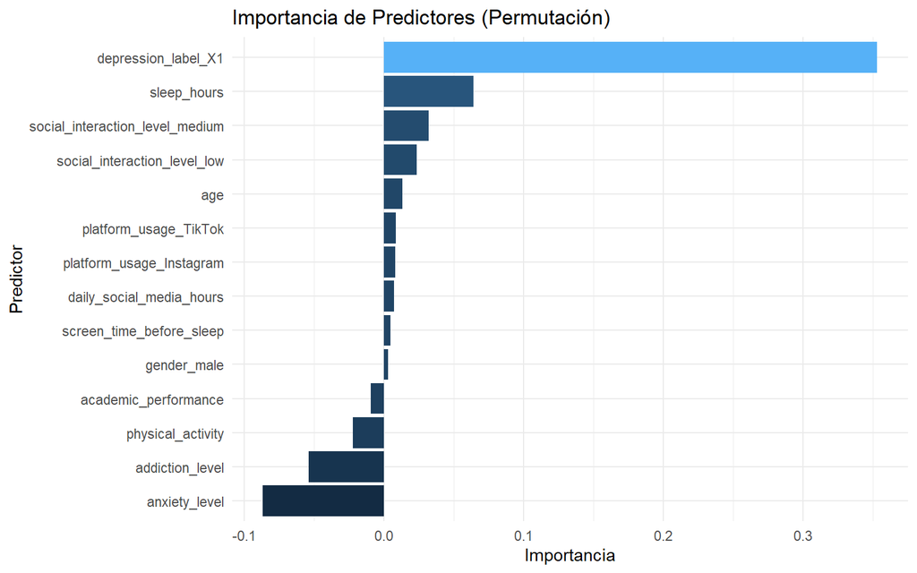

```r
ggplot(
  importancia_pred,
  aes(x = reorder(predictor, importancia), y = importancia, fill = importancia)
) +
  geom_col() +
  coord_flip() +
  labs(
    title = "Importancia de Predictores (Permutación)",
    x     = "Predictor",
    y     = "Importancia"
  ) +
  theme_minimal() +
  theme(legend.position = "none")
```

# 11 Comparación con Árbol de Decisión

```r
arbol_optimal <- rpart(
  formula = stress_level ~ .,
  data    = data_train,
  method  = "anova",
  control = list(minsplit = 6, maxdepth = 7, cp = 0.01)
)

pred_arbol <- predict(arbol_optimal, newdata = data_test)
rmse_arbol <- sqrt(mean((pred_arbol - data_test$stress_level)^2))

comparacion <- tibble(
  Modelo         = c("Árbol de Decisión", "Random Forest"),
  RMSE_Test      = c(rmse_arbol, rmse_final$.estimate),
  Mejora_vs_Base = c(
    (1 - rmse_arbol / rmse_base) * 100,
    (1 - rmse_final$.estimate / rmse_base) * 100
  )
)

print(comparacion)
```

```
## # A tibble: 2 × 3
##   Modelo            RMSE_Test Mejora_vs_Base
##   <chr>                 <dbl>          <dbl>
## 1 Árbol de Decisión      2.92           4.48
## 2 Random Forest          2.92           4.45
```

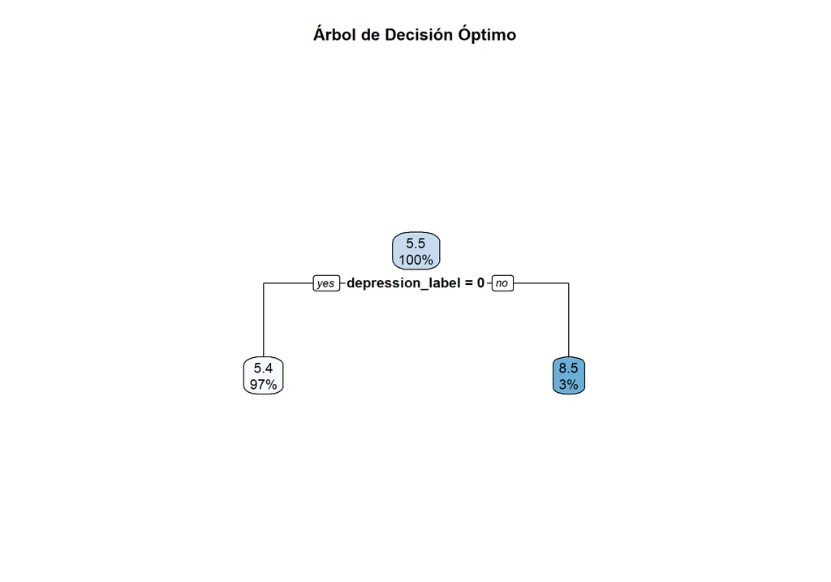

```r
rpart.plot(arbol_optimal, main = "Árbol de Decisión Óptimo")
```

# 12 Predicción con nuevos datos

```r
nuevos_datos <- data.frame(
  age                      = 16,
  gender                   = factor("female", levels = c("female", "male")),
  daily_social_media_hours = 5.0,
  platform_usage           = factor("TikTok", levels = c("Both", "Instagram", "TikTok")),
  sleep_hours              = 6.0,
  screen_time_before_sleep = 2.0,
  academic_performance     = 3.0,
  physical_activity        = 1.0,
  social_interaction_level = factor("medium", levels = c("high", "low", "medium")),
  anxiety_level            = 6,
  addiction_level          = 5,
  depression_label         = factor("0", levels = c("0", "1"))
)

pred_nuevo_arbol <- predict(arbol_optimal, newdata = nuevos_datos)
cat("Predicción (Árbol de Decisión):", round(pred_nuevo_arbol, 2), "\n")
```

```
## Predicción (Árbol de Decisión): 5.39
```

# 13 Conclusiones